#### Statistics for Laboratory Scientists ( 140.615 )

## Analysis of Variance - Two-Way Models

#### Example 1 from class: rats and lard

The data.

```r
lard.dat <- data.frame(rsp = c(709,592,679,538,699,476,657,508,594,505,677,539),
                       sex = factor(rep(c("M","F"), rep(6,2))),
                       lard = factor(rep(c("fresh","rancid"), 6)))
lard.dat
```

```
##    rsp sex   lard
## 1  709   M  fresh
## 2  592   M rancid
## 3  679   M  fresh
## 4  538   M rancid
## 5  699   M  fresh
## 6  476   M rancid
## 7  657   F  fresh
## 8  508   F rancid
## 9  594   F  fresh
## 10 505   F rancid
## 11 677   F  fresh
## 12 539   F rancid
```

```r
str(lard.dat)
```

```
## 'data.frame':    12 obs. of  3 variables:
##  $ rsp : num  709 592 679 538 699 476 657 508 594 505 ...
##  $ sex : Factor w/ 2 levels "F","M": 2 2 2 2 2 2 1 1 1 1 ...
##  $ lard: Factor w/ 2 levels "fresh","rancid": 1 2 1 2 1 2 1 2 1 2 ...
```

```r
summary(lard.dat)
```

```
##       rsp        sex       lard
##  Min.   :476.0   F:6   fresh :6
##  1st Qu.:530.5   M:6   rancid:6
##  Median :593.0
##  Mean   :597.8
##  3rd Qu.:677.5
##  Max.   :709.0
```

Plot the data, one factor at a time.

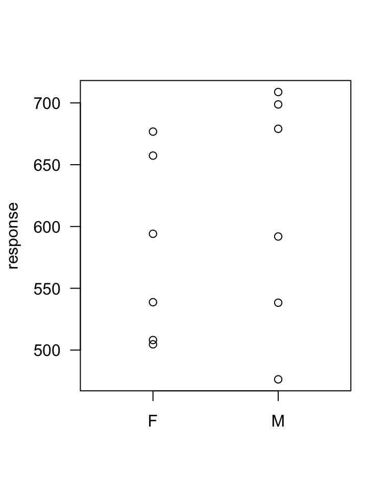

```r
set.seed(1)
par(las=1)
stripchart(jitter(rsp,factor=2) ~ sex, data=lard.dat, ylab="response", pch=1, vertical=TRUE, xlim=c(0.5,2.5))
```

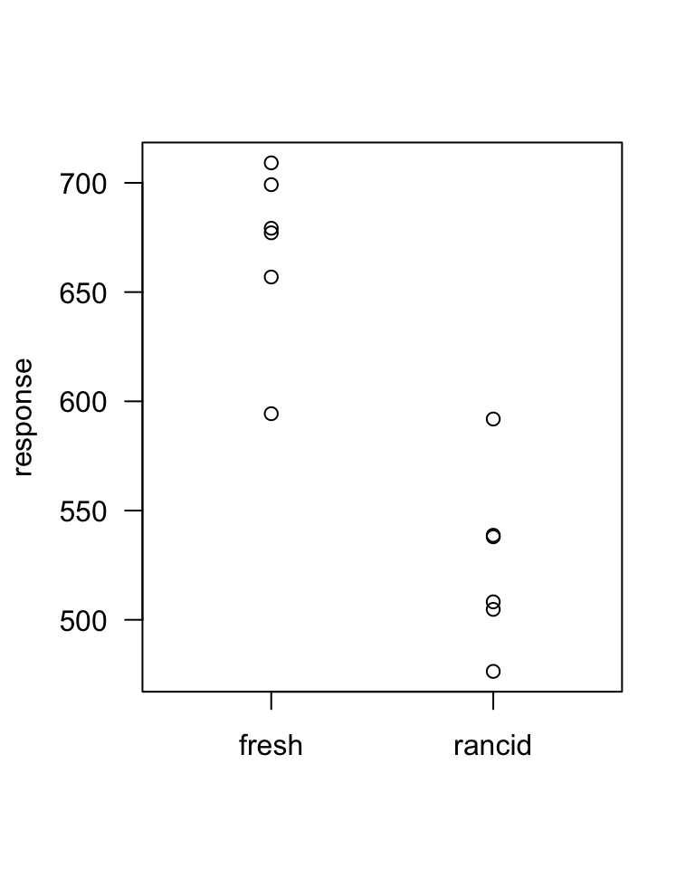

```r
stripchart(jitter(rsp,factor=2) ~ lard, data=lard.dat, ylab="response", pch=1, vertical=TRUE, xlim=c(0.5,2.5))
```

Plot the data, both factors.

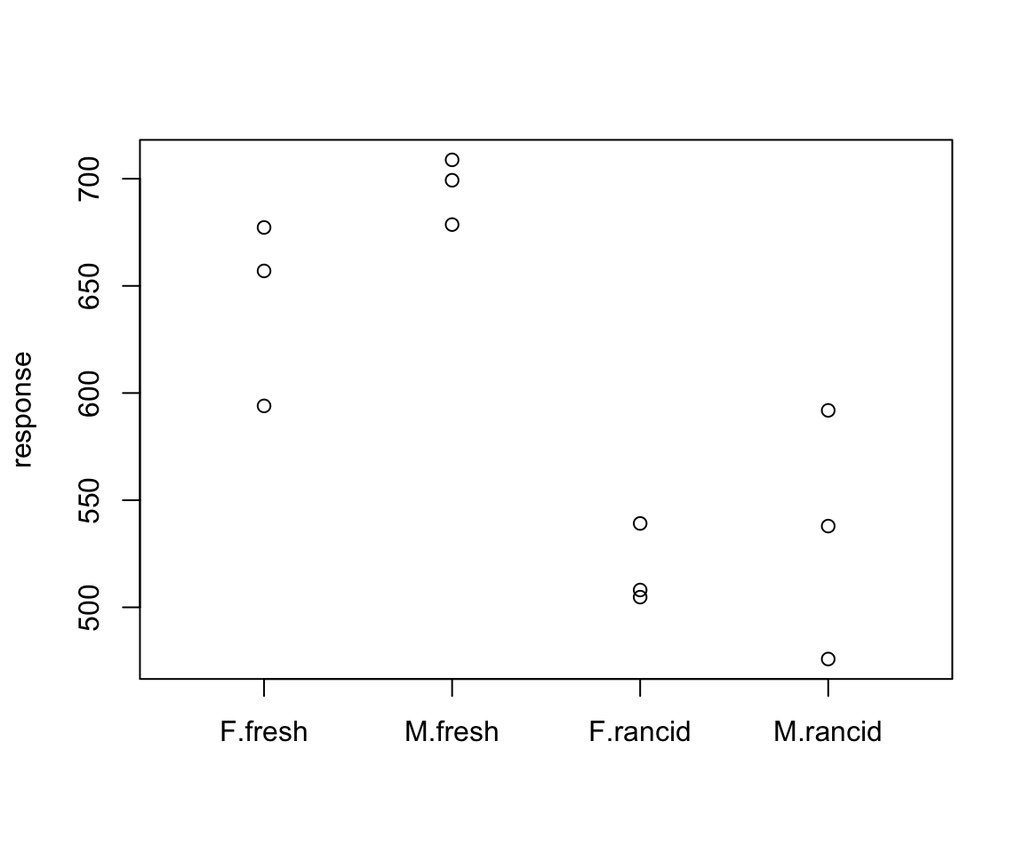

```r
stripchart(split(jitter(lard.dat$rsp,factor=2), list(lard.dat$sex, lard.dat$lard)), ylab="response", pch=1,
           vertical=TRUE, xlim=c(0.5,4.5))
```

The one-way ANOVA. The “:” symbol pastes the two factors together.

```r
summary(aov(rsp ~ sex:lard, data=lard.dat))
```

```
##             Df Sum Sq Mean Sq F value  Pr(>F)
## sex:lard     3  65904   21968   15.06 0.00118 **
## Residuals    8  11667    1458
## ---
## Signif. codes:  0 '***' 0.001 '**' 0.01 '*' 0.05 '.' 0.1 ' ' 1
```

The two-way ANOVA. The “*” symbol includes the interaction.

```r
summary(aov(rsp ~ sex * lard, data=lard.dat))
```

```
##             Df Sum Sq Mean Sq F value   Pr(>F)
## sex          1   3781    3781   2.593 0.146036
## lard         1  61204   61204  41.969 0.000192 ***
## sex:lard     1    919     919   0.630 0.450255
## Residuals    8  11667    1458
## ---
## Signif. codes:  0 '***' 0.001 '**' 0.01 '*' 0.05 '.' 0.1 ' ' 1
```

The model with interaction can also be written this way.

```r
summary(aov(rsp ~ sex + lard + sex:lard, data=lard.dat))
```

```
##             Df Sum Sq Mean Sq F value   Pr(>F)
## sex          1   3781    3781   2.593 0.146036
## lard         1  61204   61204  41.969 0.000192 ***
## sex:lard     1    919     919   0.630 0.450255
## Residuals    8  11667    1458
## ---
## Signif. codes:  0 '***' 0.001 '**' 0.01 '*' 0.05 '.' 0.1 ' ' 1
```

A two-way ANOVA with an additive model. The interaction SS are then included in the “residual” SS.

```r
summary(aov(rsp ~ sex + lard, data=lard.dat))
```

```
##             Df Sum Sq Mean Sq F value   Pr(>F)
## sex          1   3781    3781   2.704    0.135
## lard         1  61204   61204  43.768 9.75e-05 ***
## Residuals    9  12585    1398
## ---
## Signif. codes:  0 '***' 0.001 '**' 0.01 '*' 0.05 '.' 0.1 ' ' 1
```

ANOVA using only the factor lard.

```r
summary(aov(rsp ~ lard, data=lard.dat))
```

```
##             Df Sum Sq Mean Sq F value   Pr(>F)
## lard         1  61204   61204    37.4 0.000113 ***
## Residuals   10  16366    1637
## ---
## Signif. codes:  0 '***' 0.001 '**' 0.01 '*' 0.05 '.' 0.1 ' ' 1
```

The same inference using a 2-sample t-test.

```r
subset(lard.dat, lard=="fresh")
```

```
##    rsp sex  lard
## 1  709   M fresh
## 3  679   M fresh
## 5  699   M fresh
## 7  657   F fresh
## 9  594   F fresh
## 11 677   F fresh
```

```r
subset(lard.dat, lard=="rancid")
```

```
##    rsp sex   lard
## 2  592   M rancid
## 4  538   M rancid
## 6  476   M rancid
## 8  508   F rancid
## 10 505   F rancid
## 12 539   F rancid
```

```r
x <- subset(lard.dat, lard=="fresh")$rsp
x
```

```
## [1] 709 679 699 657 594 677
```

```r
y <- subset(lard.dat, lard=="rancid")$rsp
y
```

```
## [1] 592 538 476 508 505 539
```

```r
t.test(x, y, var.equal=TRUE)
```

```
##
##  Two Sample t-test
##
## data:  x and y
## t = 6.1153, df = 10, p-value = 0.0001134
## alternative hypothesis: true difference in means is not equal to 0
## 95 percent confidence interval:
##   90.7912 194.8755
## sample estimates:
## mean of x mean of y
##  669.1667  526.3333
```

```r
t.test(x, y, var.equal=TRUE)$p.val
```

```
## [1] 0.0001133845
```

```r
t.test(x, y, var.equal=TRUE)$stat
```

```
##        t
## 6.115285
```

```r
t.test(x, y, var.equal=TRUE)$stat^2
```

```
##        t
## 37.39671
```

Within-group means.

```r
means <- tapply(lard.dat$rsp, list(lard.dat$sex,lard.dat$lard), mean)
means
```

```
##      fresh   rancid
## F 642.6667 517.3333
## M 695.6667 535.3333
```

Means by sex.

```r
sex.means <- tapply(lard.dat$rsp, lard.dat$sex, mean)
sex.means
```

```
##     F     M
## 580.0 615.5
```

Means by treatment.

```r
lard.means <- tapply(lard.dat$rsp, lard.dat$lard, mean)
lard.means
```

```
##    fresh   rancid
## 669.1667 526.3333
```

An interaction plot.

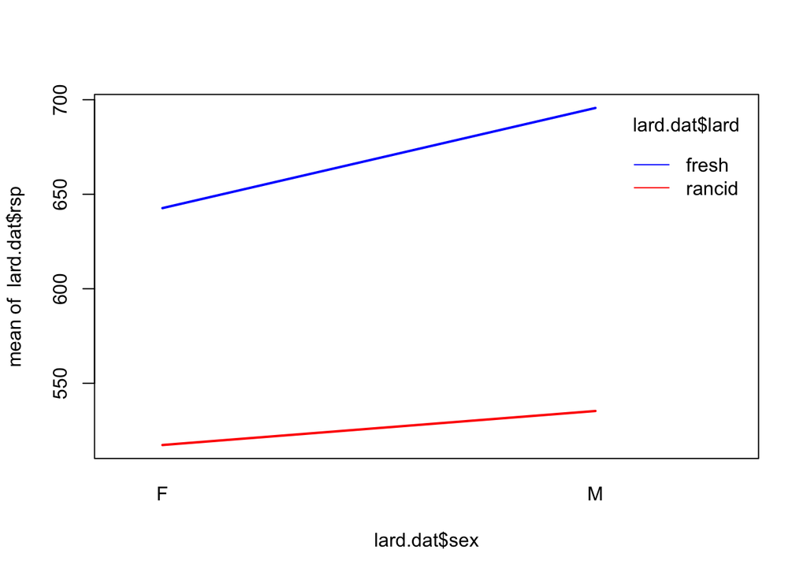

```r
interaction.plot(lard.dat$sex, lard.dat$lard, lard.dat$rsp, lty=1, col=c("blue","red"), lwd=2)
```

The same plot, but reversing the role of “sex” and “lard”.

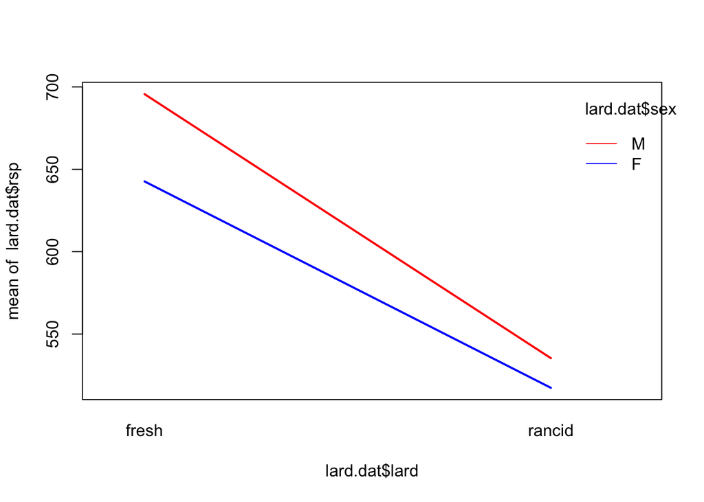

```r
interaction.plot(lard.dat$lard, lard.dat$sex, lard.dat$rsp, lty=1, col=c("blue","red"), lwd=2)
```

#### Example 2 from class: mouse, food and temperature

The data.

```r
library(SPH.140.615)
example(mouse)
```

```
##
## mouse> mouse
##       rsp         food  temp
## 1   62.69   restricted  8deg
## 2   54.07   restricted  8deg
## 3   65.73   restricted  8deg
## 4   62.98   restricted  8deg
## 5   72.60   restricted 18deg
## 6   70.97   restricted 18deg
## 7   74.32   restricted 18deg
## 8   53.02   restricted 18deg
## 9   46.22   restricted 18deg
## 10  59.10   restricted 18deg
## 11  61.79   restricted 18deg
## 12  61.89   restricted 18deg
## 13  95.73 unrestricted  8deg
## 14  63.95 unrestricted  8deg
## 15 144.30 unrestricted  8deg
## 16 144.30 unrestricted  8deg
## 17 101.19 unrestricted 18deg
## 18  76.88 unrestricted 18deg
## 19  74.08 unrestricted 18deg
## 20  81.40 unrestricted 18deg
## 21  66.58 unrestricted 18deg
## 22  84.38 unrestricted 18deg
## 23 118.95 unrestricted 18deg
## 24 118.95 unrestricted 18deg
##
## mouse> str(mouse)
## 'data.frame':    24 obs. of  3 variables:
##  $ rsp : num  62.7 54.1 65.7 63 72.6 ...
##  $ food: Factor w/ 2 levels "restricted","unrestricted": 1 1 1 1 1 1 1 1 1 1 ...
##  $ temp: Factor w/ 2 levels "18deg","8deg": 2 2 2 2 1 1 1 1 1 1 ...
##
## mouse> summary(mouse)
##       rsp                   food       temp
##  Min.   : 46.22   restricted  :12   18deg:16
##  1st Qu.: 62.49   unrestricted:12   8deg : 8
##  Median : 71.78
##  Mean   : 79.84
##  3rd Qu.: 87.22
##  Max.   :144.30
##
## mouse> tapply(mouse$rsp,list(mouse$food,mouse$temp),mean)
##                 18deg     8deg
## restricted   62.48875  61.3675
## unrestricted 90.30125 112.0700
```

Plot the data.

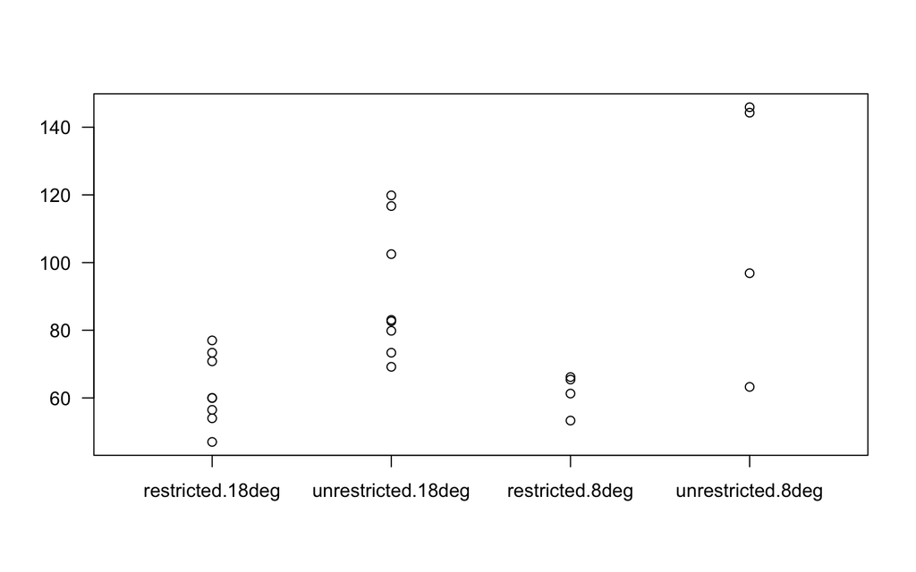

```r
set.seed(1)
par(las=1)
stripchart(split(jitter(mouse$rsp,amount=3),list(mouse$food, mouse$temp)),
           ylab="", pch=1, vertical=TRUE, xlim=c(0.5,4.5))
```

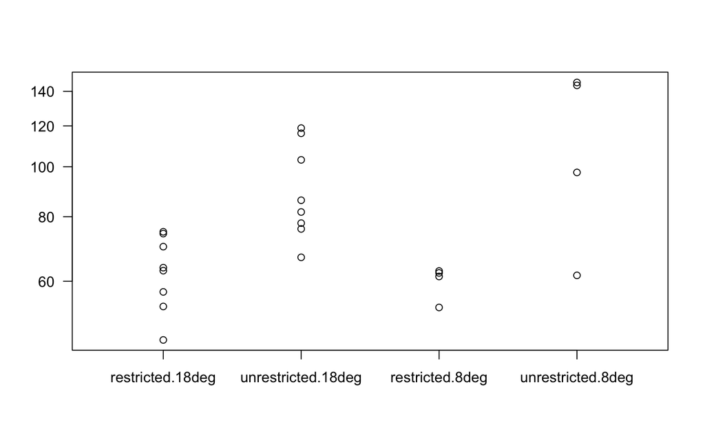

```r
stripchart(split(jitter(mouse$rsp,amount=3),list(mouse$food, mouse$temp)),
           ylab="", pch=1, vertical=TRUE, xlim=c(0.5,4.5), log="y")
```

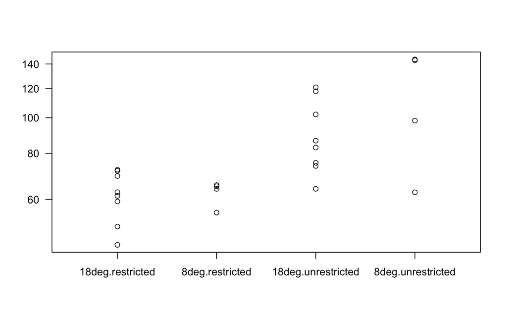

```r
stripchart(split(jitter(mouse$rsp,amount=3),list(mouse$temp, mouse$food)),
           ylab="", pch=1, vertical=TRUE, xlim=c(0.5,4.5), log="y")
```

Numbers of individuals per condition,

```r
tapply(mouse$rsp, list(mouse$food, mouse$temp), length)
```

```
##              18deg 8deg
## restricted       8    4
## unrestricted     8    4
```

The two-way ANOVA, with log-transformed response.

```r
aov.out <- aov(log(rsp) ~ food * temp, data=mouse)
summary(aov.out)
```

```
##             Df Sum Sq Mean Sq F value   Pr(>F)
## food         1 1.0725  1.0725  21.421 0.000162 ***
## temp         1 0.0407  0.0407   0.813 0.378025
## food:temp    1 0.0498  0.0498   0.995 0.330479
## Residuals   20 1.0014  0.0501
## ---
## Signif. codes:  0 '***' 0.001 '**' 0.01 '*' 0.05 '.' 0.1 ' ' 1
```

The interaction plot

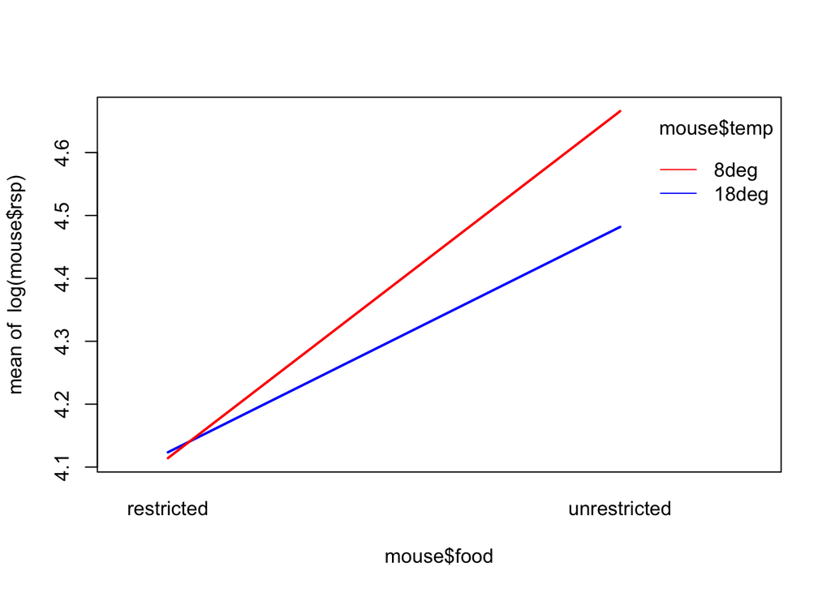

```r
interaction.plot(mouse$food, mouse$temp, log(mouse$rsp), lwd=2, col=c("blue","red"), lty=1)
```

Reverse role of food and temperature.

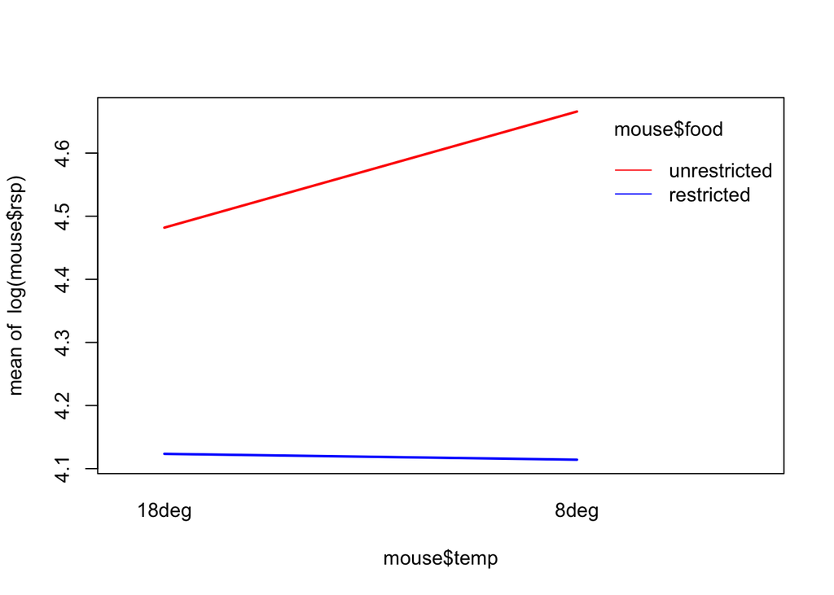

```r
interaction.plot(mouse$temp, mouse$food, log(mouse$rsp), lwd=2, col=c("blue","red"), lty=1)
```

Two-way ANOVA without interaction.

```r
aov.out <- aov(log(rsp) ~ food + temp, data=mouse)
summary(aov.out)
```

```
##             Df Sum Sq Mean Sq F value   Pr(>F)
## food         1 1.0725  1.0725  21.426 0.000145 ***
## temp         1 0.0407  0.0407   0.813 0.377463
## Residuals   21 1.0512  0.0501
## ---
## Signif. codes:  0 '***' 0.001 '**' 0.01 '*' 0.05 '.' 0.1 ' ' 1
```

ANOVA only using the factor food.

```r
aov.out <- aov(log(rsp) ~ food, data=mouse)
anova(aov.out)
```

```
## Analysis of Variance Table
##
## Response: log(rsp)
##           Df Sum Sq Mean Sq F value    Pr(>F)
## food       1 1.0725 1.07250   21.61 0.0001238 ***
## Residuals 22 1.0919 0.04963
## ---
## Signif. codes:  0 '***' 0.001 '**' 0.01 '*' 0.05 '.' 0.1 ' ' 1
```

#### Example 3 from class: flies, density, strain, no replicates

The data.

```r
flies <- data.frame(rsp = c( 9.6, 9.3, 9.3,
                            10.6, 9.1, 9.2,
                             9.8, 9.3, 9.5,
                            10.7, 9.1,10.0,
                            11.1,11.1,10.4,
                            10.9,11.8,10.8,
                            12.8,10.6,10.7),
                   strain = factor(rep(c("OL","BELL","bwb"),7)),
                   density = factor(rep(c(60,80,160,320,640,1280,2560),rep(3,7))))
summary(flies)
```

```
##       rsp         strain  density
##  Min.   : 9.10   BELL:7   60  :3
##  1st Qu.: 9.30   bwb :7   80  :3
##  Median :10.40   OL  :7   160 :3
##  Mean   :10.27            320 :3
##  3rd Qu.:10.80            640 :3
##  Max.   :12.80            1280:3
##                           2560:3
```

Plot the data.

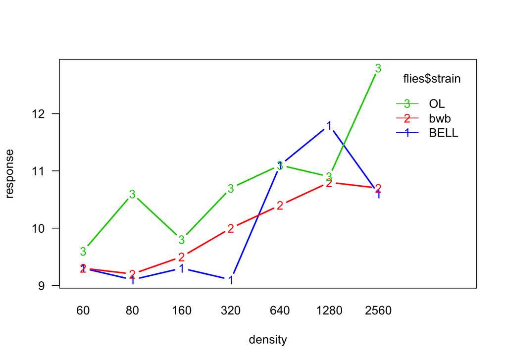

```r
par(las=1)
interaction.plot(flies$density, flies$strain, flies$rsp, lwd=2, col=c("blue","red","green3"), lty=1, type="b",
                 xlab="density", ylab="response")
```

Note: we can’t fit an interaction. If we try, we have no ability to get an error SS, so we don’t get p-values either.

```r
flies.aovA <- aov(rsp ~ strain * density, data=flies)
summary(flies.aovA)
```

```
##                Df Sum Sq Mean Sq
## strain          2  2.789  1.3943
## density         6 12.543  2.0905
## strain:density 12  4.111  0.3426
```

Assume an additive model.

```r
flies.aovB = aov(rsp ~ strain + density, data=flies)
summary(flies.aovB)
```

```
##             Df Sum Sq Mean Sq F value  Pr(>F)
## strain       2  2.789  1.3943   4.069 0.04476 *
## density      6 12.543  2.0905   6.101 0.00395 **
## Residuals   12  4.111  0.3426
## ---
## Signif. codes:  0 '***' 0.001 '**' 0.01 '*' 0.05 '.' 0.1 ' ' 1
```